# Lab 10

Mary McCloskey

2024-03-27

```r
library(tidyverse)
```

```r
library(dplyr)
library(plotly)
library(knitr)
library(DT)
```

# NEON Wind River Experimental Forest

[NEON Site Page](https://www.neonscience.org/field-sites/wref)

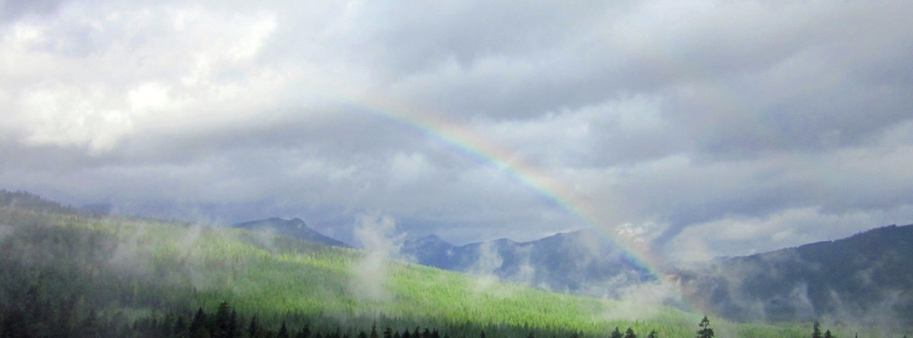

The Wind River Experimental Forest (WREF) is located in Washington, USA. It has been used for various reserach projects since 1909. NEON has been using the site for soil samples since summer 2018.

The mean annual temperature is 9.2’C, with 2225mm of yearly precipitation, and is considered an Evergreen Forest. The soil type is classified as vitric hapludands. (“Wind River Experimental Forest NEON / WREF,” n.d.)

## Metagenome Information

```r
IMGmetadata <- read_tsv("data/exported_img_data(1).tsv")
datatable(
  IMGmetadata %>%
  filter(str_detect(`Genome Name / Sample Name`, "Wind River"))
)
```

|  | taxon_oid | Domain | Sequencing Status | Study Name | Genome Name / Sample Name | Sequencing Center | IMG Genome ID | Ecosystem Subtype | Latitude | Longitude | Genome Size * assembled | Gene Count * assembled |
| --- | --- | --- | --- | --- | --- | --- | --- | --- | --- | --- | --- | --- |
| 1 | 3300060667 | *Microbiome | Permanent Draft | Terrestrial soil microbial communities from various NEON sites located in USA and Puerto Rico | Terrestrial soil microbial communities from Wind River Experimental Forest, Washington, USA - WREF_073-M-20210623-comp-1 | DOE Joint Genome Institute (JGI) | 3300060667 | Temperate forest | 45.825842 | -121.960125 | 1515078457 | 2718795 |
| 2 | 3300069296 | *Microbiome | Permanent Draft | Terrestrial soil microbial communities from various NEON sites located in USA and Puerto Rico | Terrestrial soil microbial communities from Wind River Experimental Forest, Washington, USA - WREF_004-M-20210622-comp-1 re-annotation | DOE Joint Genome Institute (JGI) | 3300069296 | Temperate forest | 45.822941 | -121.998707 | 3074038485 | 7283581 |
| 3 | 3300060655 | *Microbiome | Permanent Draft | Terrestrial soil microbial communities from various NEON sites located in USA and Puerto Rico | Terrestrial soil microbial communities from Wind River Experimental Forest, Washington, USA - WREF_073-O-20210623-comp-1 | DOE Joint Genome Institute (JGI) | 3300060655 | Temperate forest | 45.825842 | -121.960125 | 1243731233 | 2155346 |
| 4 | 3300069294 | *Microbiome | Permanent Draft | Terrestrial soil microbial communities from various NEON sites located in USA and Puerto Rico | Terrestrial soil microbial communities from Wind River Experimental Forest, Washington, USA - WREF_004-O-20210622-comp-1 re-annotation | DOE Joint Genome Institute (JGI) | 3300069294 | Temperate forest | 45.822941 | -121.998707 | 1608202383 | 3813261 |
| 5 | 3300061179 | *Microbiome | Permanent Draft | Terrestrial soil microbial communities from various NEON sites located in USA and Puerto Rico | Terrestrial soil microbial communities from Wind River Experimental Forest, Washington, USA - WREF_001-O-20210621-comp-1 | DOE Joint Genome Institute (JGI) | 3300061179 | Temperate forest | 45.844033 | -121.999068 | 3068129637 | 4918035 |
| 6 | 3300060889 | *Microbiome | Permanent Draft | Terrestrial soil microbial communities from various NEON sites located in USA and Puerto Rico | Terrestrial soil microbial communities from Wind River Experimental Forest, Washington, USA - WREF_004-O-20210622-comp-1 | DOE Joint Genome Institute (JGI) | 3300060889 | Temperate forest | 45.822941 | -121.998707 | 917531332 | 1560190 |
| 7 | 3300069221 | *Microbiome | Permanent Draft | Terrestrial soil microbial communities from various NEON sites located in USA and Puerto Rico | Terrestrial soil microbial communities from Wind River Experimental Forest, Washington, USA - WREF_073-M-20210623-comp-1 re-annotation | DOE Joint Genome Institute (JGI) | 3300069221 | Temperate forest | 45.825842 | -121.960125 | 2870846305 | 7170804 |
| 8 | 3300069255 | *Microbiome | Permanent Draft | Terrestrial soil microbial communities from various NEON sites located in USA and Puerto Rico | Terrestrial soil microbial communities from Wind River Experimental Forest, Washington, USA - WREF_003-M-20210622-comp-1 re-annotation | DOE Joint Genome Institute (JGI) | 3300069255 | Temperate forest | 45.831516 | -122.018608 | 3072198400 | 6638642 |
| 9 | 3300060779 | *Microbiome | Permanent Draft | Terrestrial soil microbial communities from various NEON sites located in USA and Puerto Rico | Terrestrial soil microbial communities from Wind River Experimental Forest, Washington, USA - WREF_004-M-20210622-comp-1 | DOE Joint Genome Institute (JGI) | 3300060779 | Temperate forest | 45.822941 | -121.998707 | 1814049538 | 3169050 |
| 10 | 3300060780 | *Microbiome | Permanent Draft | Terrestrial soil microbial communities from various NEON sites located in USA and Puerto Rico | Terrestrial soil microbial communities from Wind River Experimental Forest, Washington, USA - WREF_003-M-20210622-comp-1 | DOE Joint Genome Institute (JGI) | 3300060780 | Temperate forest | 45.831516 | -122.018608 | 2081512039 | 3450446 |

[output cut: 4 more lines]

## MAGs Presentn at WREF

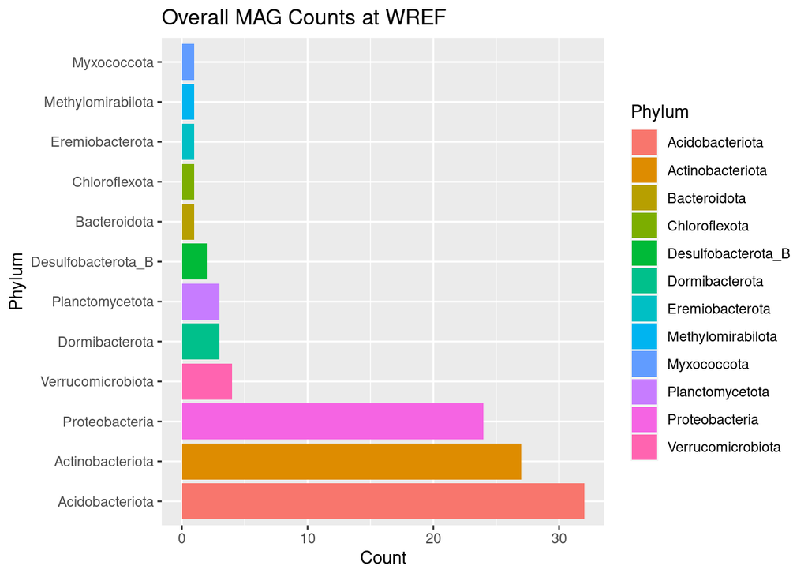

```r
NEON_MAGs <- read_csv("data/NEON/GOLD_Study_ID_Gs0161344_NEON_edArchaea.csv") %>%
  # remove columns that are not needed for data analysis
  select(-c(`GOLD Study ID`, `Bin Methods`, `Created By`, `Date Added`)) %>%
  # create a new column with the Assembly Type
  mutate("Assembly Type" = case_when(`Genome Name` == "NEON combined assembly" ~ `Genome Name`,
                            TRUE ~ "Individual")) %>%
  mutate_at("Assembly Type", str_replace, "NEON combined assembly", "Combined") %>%
  separate(`GTDB-Tk Taxonomy Lineage`, c("Domain", "Phylum", "Class", "Order", "Family", "Genus"), "; ", remove = FALSE) %>%
  # Get rid of the the common string "Soil microbial communities from "
  mutate_at("Genome Name", str_replace, "Terrestrial soil microbial communities from ", "") %>%
  # Use the first `-` to split the column in two
  separate(`Genome Name`, c("Site","Sample Name"), " - ") %>%
  # Get rid of the the common string "S-comp-1"
  mutate_at("Sample Name", str_replace, "-comp-1", "") %>%
  # separate the Sample Name into Site ID and plot info
  separate(`Sample Name`, c("Site ID","subplot.layer.date"), "_", remove = FALSE,) %>%
  # separate the plot info into 3 columns
  separate(`subplot.layer.date`, c("Subplot", "Layer", "Date"), "-")
NEON_MAGs %>%
  filter(Site == "Wind River Experimental Forest, Washington, USA") %>%
ggplot(aes(x = fct_infreq(Phylum), fill = Phylum)) +
  geom_bar() + ggtitle("Overall MAG Counts at WREF") + xlab("Phylum") + ylab("Count") +
  coord_flip()
```

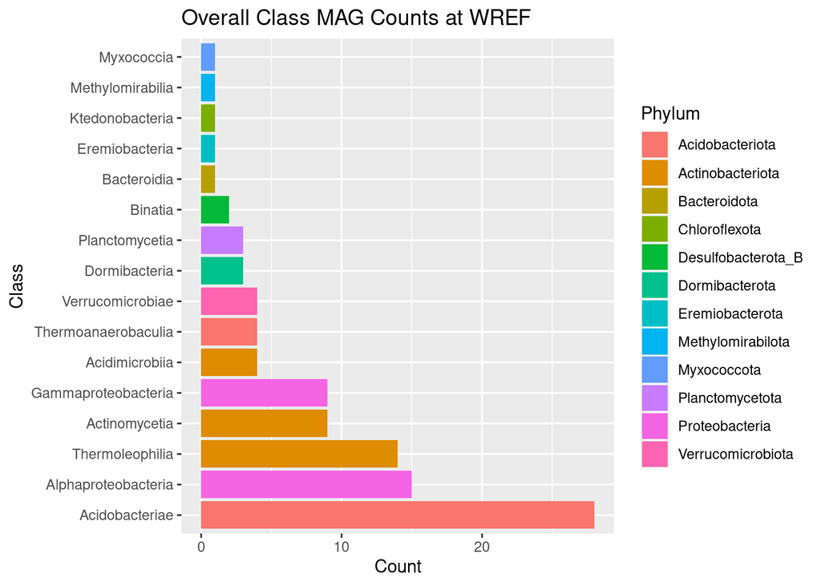

```r
NEON_MAGs %>%
  filter(Site == "Wind River Experimental Forest, Washington, USA") %>%
ggplot(aes(x = fct_infreq(Class), fill = Phylum)) +
  geom_bar() + ggtitle("Overall Class MAG Counts at WREF") + xlab("Class") + ylab("Count") +
  coord_flip()
```

## An Overview of Acidobacteriota

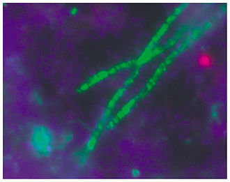

Acidobacterium (image: Wikipedia)

Acidobacteriota are a diverse phylum of bacteria that can be found in many different habitats, such as soil, oceans, caves, and hot springs. Most members of this phylum are acidophilic. Despite how common they are, not much is known about acidobacteria, as they are difficult to grow in culture. (“Acidobacteriota,” n.d.)

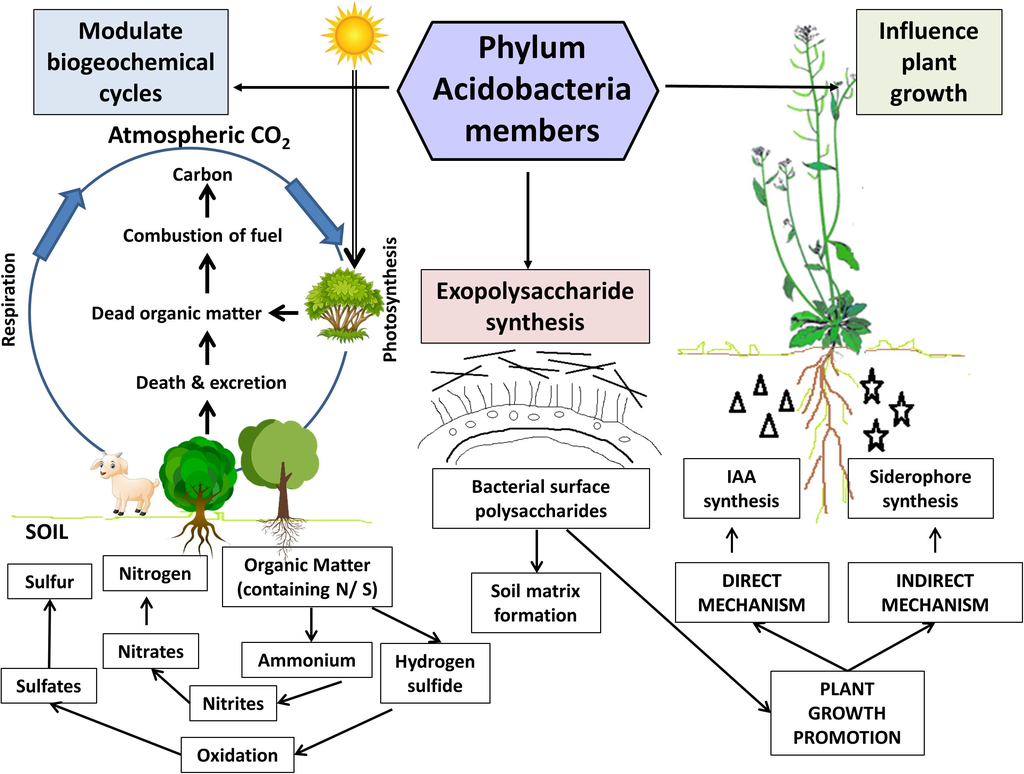

The role of acidobacteria in the ecosystem (image: Kalam et al 2020)

Acidobacteria are believed to play several ecological roles, such as plant-growth promoting rhizobacteria, decomposers, especially of complex carbohydrates, as well as sulfur metabolism. They are also considered keystone taxa, which are taxa that are important for the stability of the ecosystem, in grasslands, forests, and agricultural soils. (Kalam et al. 2020)

## Acidobacteria in NEON Sites

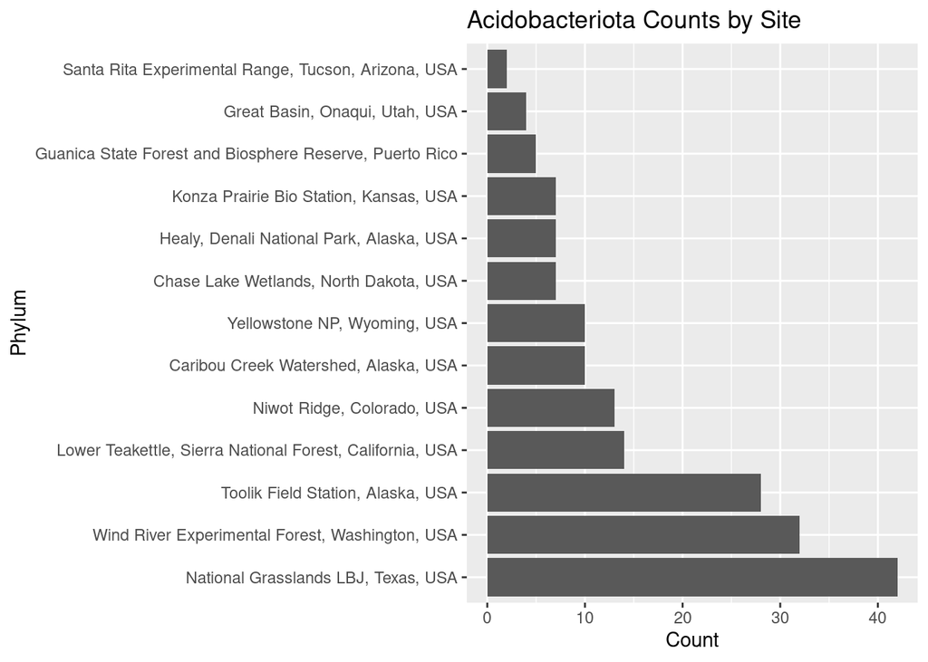

```r
NEON_MAGs %>%
  filter(Phylum == "Acidobacteriota") %>%
  filter(Site != "NEON combined assembly") %>%
ggplot(aes(x = fct_infreq(Site))) +
  geom_bar() + ggtitle("Acidobacteriota Counts by Site") + xlab("Phylum") + ylab("Count") +
  coord_flip()
```

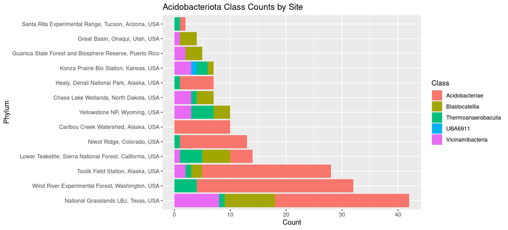

```r
NEON_MAGs %>%
  filter(Phylum == "Acidobacteriota") %>%
  filter(Site != "NEON combined assembly") %>%
ggplot(aes(x = fct_infreq(Site), fill = Class)) +
  geom_bar() + ggtitle("Acidobacteriota Class Counts by Site") + xlab("Phylum") + ylab("Count") +
  coord_flip()
```

# References

“Acidobacteriota.” n.d. *Wikipedia*. https://en.wikipedia.org/wiki/Acidobacteriota.

Kalam, Sadaf, Anirban Basu, Iqbal Ahmad, R. Z. Sayyed, Hesham Ali El-Enshasy, Daniel Joe Dailin, and Ni Luh Suriani. 2020. “Recent Understanding of Soil Acidobacteria and Their Ecological Significance: A Critical Review.” *Frontiers in Microbiology* 11 (October). https://doi.org/10.3389/fmicb.2020.580024.

“Wind River Experimental Forest NEON / WREF.” n.d. *NEON Science*. https://www.neonscience.org/field-sites/wref.